# Biostat 203B Homework 2

Due Feb 5 @ 11:59PM

Siyan (Clare) Chen

```r
knitr::opts_chunk$set(echo = TRUE, cache = TRUE)
library(tidyverse)
library(data.table)
library(lubridate)
library(dplyr)
```

```r
os <- sessionInfo()$running
if (str_detect(os, "Linux")) {
  mimic_path <- "/usr/203b-data/mimic-iv"
} else if (str_detect(os, "macOS")) {
  mimic_path <- "/Users/huazhou/Documents/Box Sync/MIMIC/mimic-iv-0.4"
}
```

Use tidyverse (ggpot2, dplyr) to explore the [MIMIC-IV](https://mimic-iv.mit.edu) data introduced in [homework 1](https://ucla-biostat203b-2021winter.github.io/hw/hw1/hw1.html).

```r
system(str_c("tree -s -L 2 ", shQuote(mimic_path)), intern = TRUE)
```

```
##  [1] "/usr/203b-data/mimic-iv"
##  [2] "├── [         78]  core"
##  [3] "│   ├── [   17224843]  admissions.csv.gz"
##  [4] "│   ├── [    2884996]  patients.csv.gz"
##  [5] "│   └── [   51188147]  transfers.csv.gz"
##  [6] "├── [       4096]  hosp"
##  [7] "│   ├── [     430049]  d_hcpcs.csv.gz"
##  [8] "│   ├── [   26575586]  diagnoses_icd.csv.gz"
##  [9] "│   ├── [     723633]  d_icd_diagnoses.csv.gz"
## [10] "│   ├── [     564422]  d_icd_procedures.csv.gz"
## [11] "│   ├── [      14845]  d_labitems.csv.gz"
## [12] "│   ├── [   12913088]  drgcodes.csv.gz"
## [13] "│   ├── [  518077567]  emar.csv.gz"
## [14] "│   ├── [  479709397]  emar_detail.csv.gz"
## [15] "│   ├── [    1415469]  hcpcsevents.csv.gz"
```

[output cut: 20 more lines]

## Q1. PhysioNet credential

At this moment, you should already get credentialed on the PhysioNet. Please include a screenshot of your `Data Use Agreement for the MIMIC-IV (v0.4)`.

### Solution:

[figure not shown]

## Q2. `read.csv` (base R) vs `read_csv` (tidyverse) vs `fread` (data.table)

There are quite a few utilities in R for reading data files. Let us test the speed of reading a moderate sized compressed csv file, `admissions.csv.gz`, by three programs: `read.csv` in base R, `read_csv` in tidyverse, and `fread` in the popular data.table package. Is there any speed difference?

In this homework, we stick to the tidyverse.

### Solution

```r
system.time(fread("/usr/203b-data/mimic-iv/core/admissions.csv.gz"))
```

```
##    user  system elapsed
##   5.202   0.424   4.129
```

```r
system.time(read_csv("/usr/203b-data/mimic-iv/core/admissions.csv.gz"))
```

```
##    user  system elapsed
##   4.427   0.154   5.093
```

```r
system.time(read.csv("/usr/203b-data/mimic-iv/core/admissions.csv.gz"))
```

[output not shown]

## Q3. ICU stays

`icustays.csv.gz` (https://mimic-iv.mit.edu/docs/datasets/icu/icustays/) contains data about Intensive Care Units (ICU) stays. Summarize following variables using appropriate numerics or graphs:

- how many unique `stay_id`?
- how many unique `subject_id`?
- length of ICU stay
- first ICU unit
- last ICU unit

### Solution:

Read in ‘icustays’ data.

```r
icustays <- read_csv("/usr/203b-data/mimic-iv/icu/icustays.csv.gz") %>%
  print(width = Inf, n = 10)
```

```
## # A tibble: 69,619 x 8
##    subject_id  hadm_id  stay_id first_careunit
##         <dbl>    <dbl>    <dbl> <chr>
##  1   17823467 27561644 35964304 Coronary Care Unit (CCU)
##  2   15772648 26147926 39637383 Trauma SICU (TSICU)
##  3   13713711 25848902 36363748 Trauma SICU (TSICU)
##  4   13173210 22338446 38210858 Coronary Care Unit (CCU)
##  5   10213765 28522861 39765853 Trauma SICU (TSICU)
##  6   17530304 21776160 35848367 Trauma SICU (TSICU)
##  7   10297774 20364526 37788595 Coronary Care Unit (CCU)
##  8   16766597 21185791 39262919 Trauma SICU (TSICU)
##  9   17684317 28656350 36989766 Trauma SICU (TSICU)
## 10   15693895 21203492 34766377 Surgical Intensive Care Unit (SICU)
##    last_careunit                       intime              outtime
##    <chr>                               <dttm>              <dttm>
```

[output cut: 23 more lines]

- Check for numbers of unique ‘stay_id’: 69619

```r
icustays %>%
  distinct(stay_id) %>%
  nrow()
```

```
## [1] 69619
```

- Check for numbers of unique ‘subject_id’: 50048

```r
icustays %>%
  distinct(subject_id) %>%
  nrow()
```

```
## [1] 50048
```

- Length of ICU stays:

To make the graph more clear, logrithm transformation has been applied to the value of x: length of ICU stays.

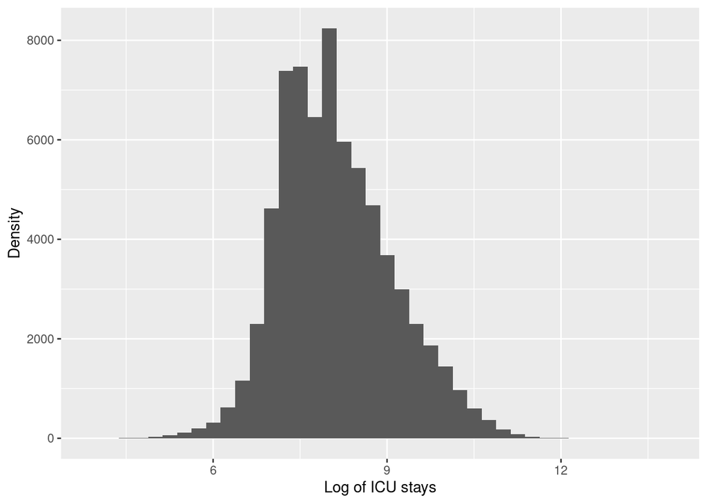

```r
icustays %>%
  mutate(length = as.numeric(outtime - intime)) %>%
  select(length) %>%
  ggplot(aes(x = log(length))) +
  geom_histogram(bins = 40) +
  xlab("Log of ICU stays") +
  ylab("Density")
```

We can use the data los given in the dataset directly:

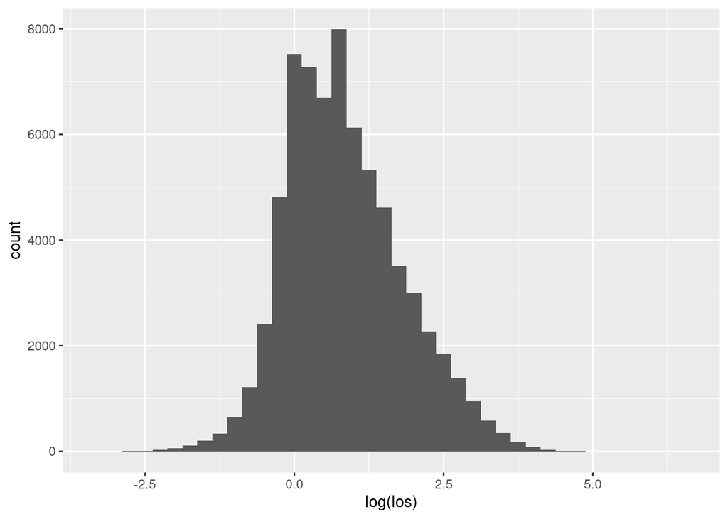

```r
icustays %>%
  ggplot() +
  geom_histogram(aes(x = log(los)), bins = 40)
```

Note that the histograms from the above two methods are approximately the same.

- First ICU unit

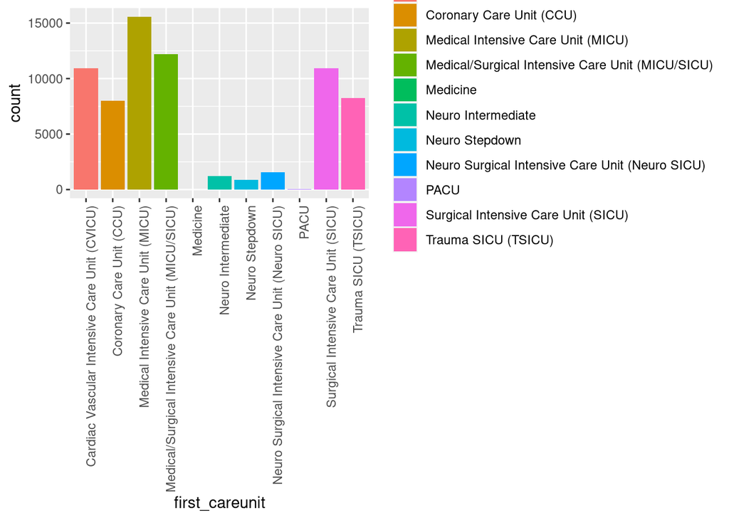

```r
icustays %>%
  select(first_careunit) %>%
  ggplot(aes(x = first_careunit)) +
  geom_bar(mapping = aes(fill = first_careunit)) +
  theme(axis.text.x = element_text(angle = 90, hjust = 1))
```

- last ICU unit

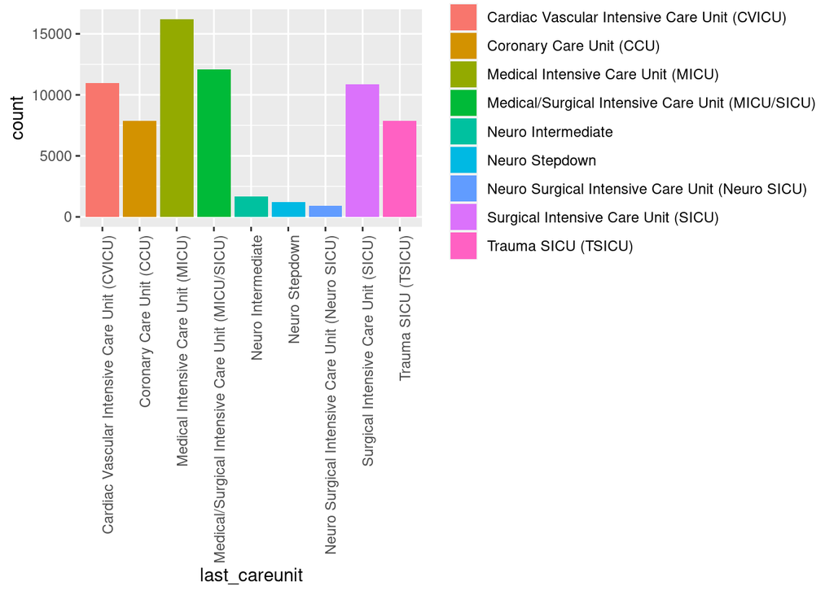

```r
icustays %>%
  select(last_careunit) %>%
  ggplot(aes(x=last_careunit)) +
  geom_bar(mapping = aes(fill = last_careunit)) +
  theme(axis.text.x = element_text(angle = 90, hjust = 1))
```

## Q4. `admission` data

Information of the patients admitted into hospital is available in `ADMISSION.csv.gz`. See https://mimic-iv.mit.edu/docs/datasets/core/admissions/ for details of each field in this file. Summarize following variables using appropriate graphs. Explain any patterns you observe.

### Solution

```r
admission <- read_csv("/usr/203b-data/mimic-iv/core/admissions.csv.gz") %>%
  print(width = Inf)
```

```
## # A tibble: 524,520 x 15
##    subject_id  hadm_id admittime           dischtime
##         <dbl>    <dbl> <dttm>              <dttm>
##  1   12427812 21593330 2184-01-06 11:51:00 2184-01-10 11:45:00
##  2   14029832 22059088 2120-01-18 01:28:00 2120-01-20 16:13:00
##  3   14495017 22484010 2175-01-28 15:41:00 2175-01-29 16:00:00
##  4   13676048 23865469 2193-01-19 05:27:00 2193-01-24 18:59:00
##  5   13831972 27763544 2131-01-27 04:03:00 2131-01-27 05:39:00
##  6   18523038 25414328 2142-08-26 17:14:00 2142-08-27 10:00:00
##  7   16705931 20580522 2174-10-24 11:30:00 2174-10-24 18:45:00
##  8   19963742 24951506 2171-07-04 15:58:00 2171-07-05 13:37:00
##  9   10903424 22568585 2181-01-31 13:09:00 2181-01-31 13:42:00
## 10   15030422 21975876 2149-09-21 23:54:00 2149-09-22 03:59:00
##    deathtime           admission_type         admission_location
##    <dttm>              <chr>                  <chr>
```

[output cut: 35 more lines]

- admission year

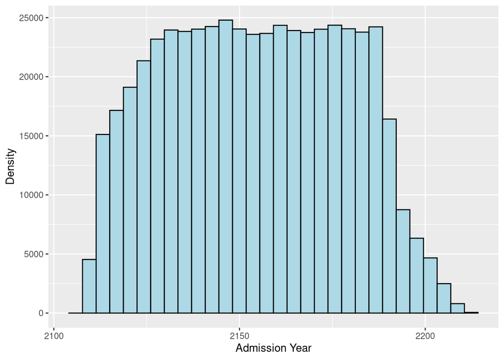

```r
admission %>%
  distinct(., subject_id, .keep = T) %>%
  ggplot(data = admission, mapping = aes(x = admittime)) +
  geom_histogram(color = 'black', fill = 'lightblue', bin = 30) +
  xlab("Admission Year") +
  ylab("Density")
```

- admission month

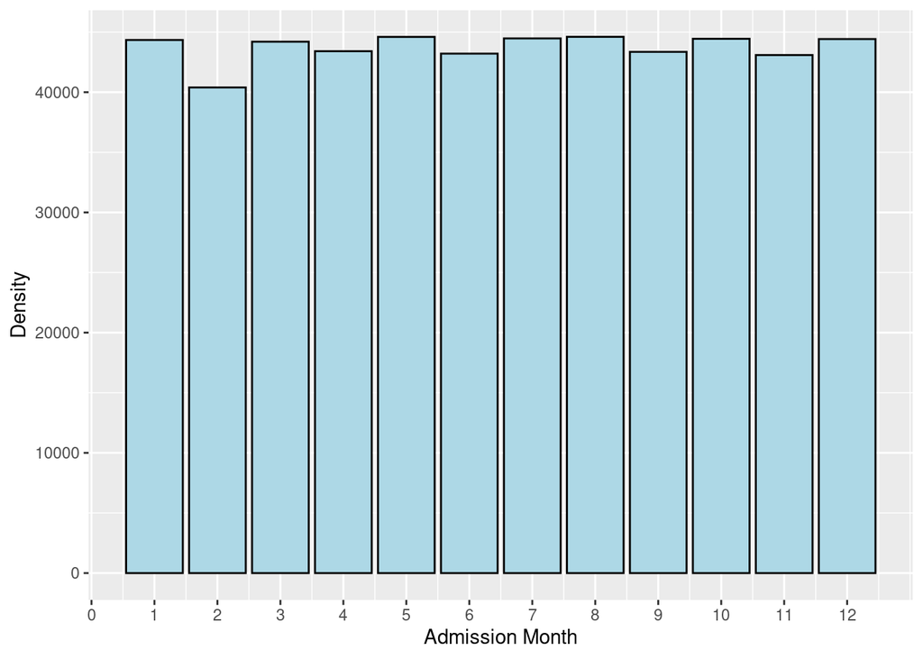

```r
admission %>%
  distinct(., subject_id, .keep = T) %>%
  ggplot(data = admission, mapping = aes(x = month(admittime))) +
  geom_bar(color = 'black', fill = 'lightblue') +
  xlab("Admission Month") +
  ylab("Density") +
  scale_x_continuous(breaks=seq(0, 12, 1))
```

- admission month day

Looks like there is a peak on 14th.

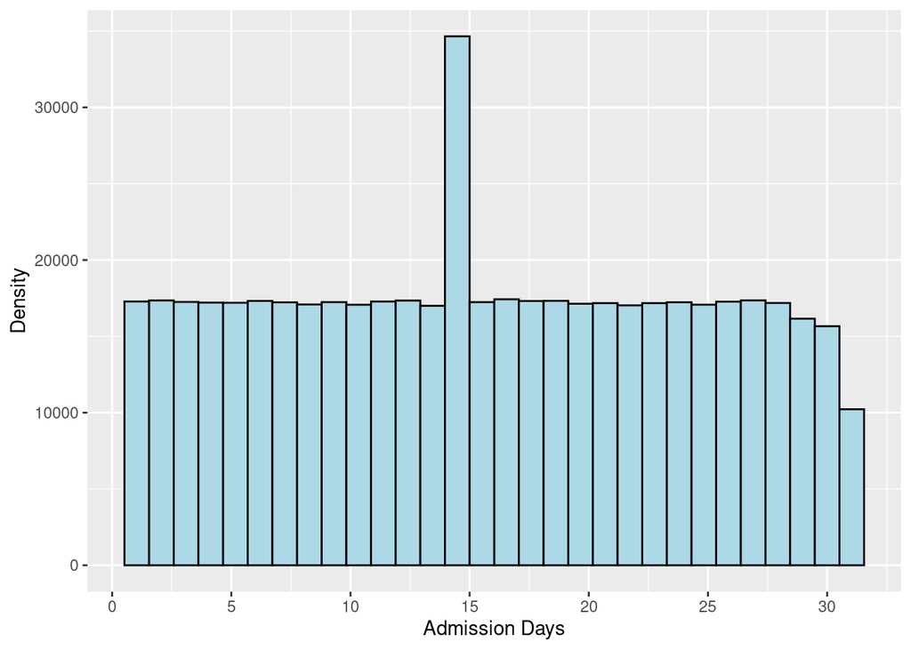

```r
admission %>%
  distinct(., subject_id, .keep = T) %>%
  ggplot(data = admission, mapping = aes(x = mday(admittime))) +
    geom_histogram(color = 'black', fill = 'lightblue', bin = 5) +
    xlab("Admission Days") +
    ylab("Density") +
    scale_x_continuous(breaks=seq(0, 31, 5))
```

- admission week day

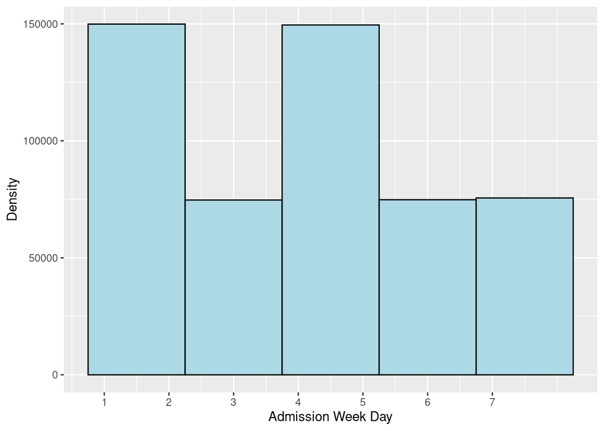

```r
admission %>%
  distinct(., subject_id, .keep = T) %>%
  ggplot(data = admission, mapping = aes(x = wday(admittime))) +
    geom_histogram(color = 'black', fill = 'lightblue', bins = 5) +
    xlab("Admission Week Day") +
    ylab("Density") +
    scale_x_continuous(breaks=seq(0, 7, 1))
```

- admission hour (anything unusual?)

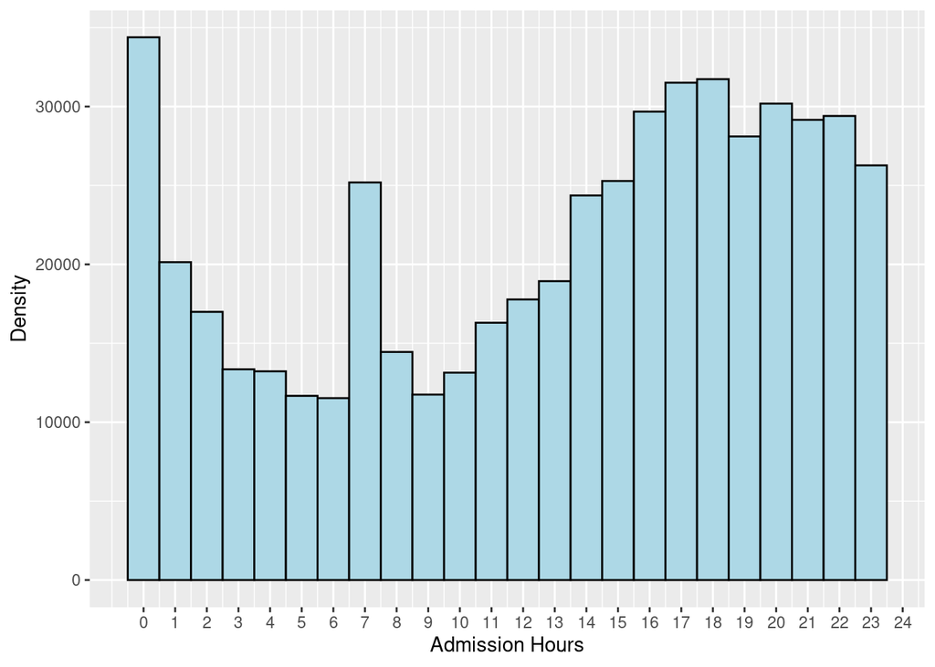

```r
admission %>%
  distinct(., subject_id, .keep = T) %>%
  ggplot(data = admission, mapping = aes(x = hour(admittime))) +
    geom_histogram(color = 'black', fill = 'lightblue', bins = 24) +
    xlab("Admission Hours") +
    ylab("Density") +
    scale_x_continuous(breaks=seq(0, 24, 1))
```

- number of deaths in each year

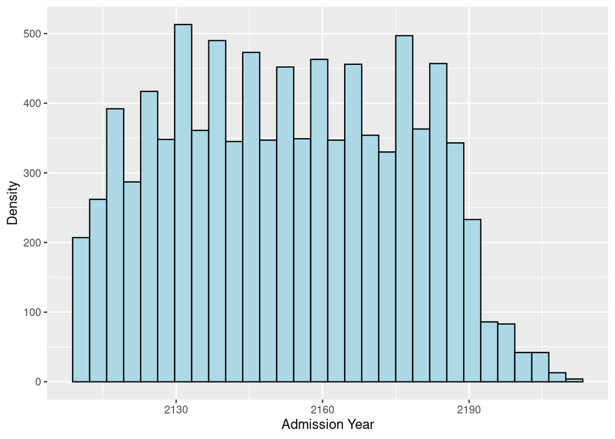

```r
admission %>%
  distinct(., subject_id, .keep = T) %>%
  ggplot(data = admission, mapping = aes(x = year(deathtime))) +
  geom_histogram(color = 'black', fill = 'lightblue', bin = 30) +
  xlab("Admission Year") +
  ylab("Density")
```

- admission type

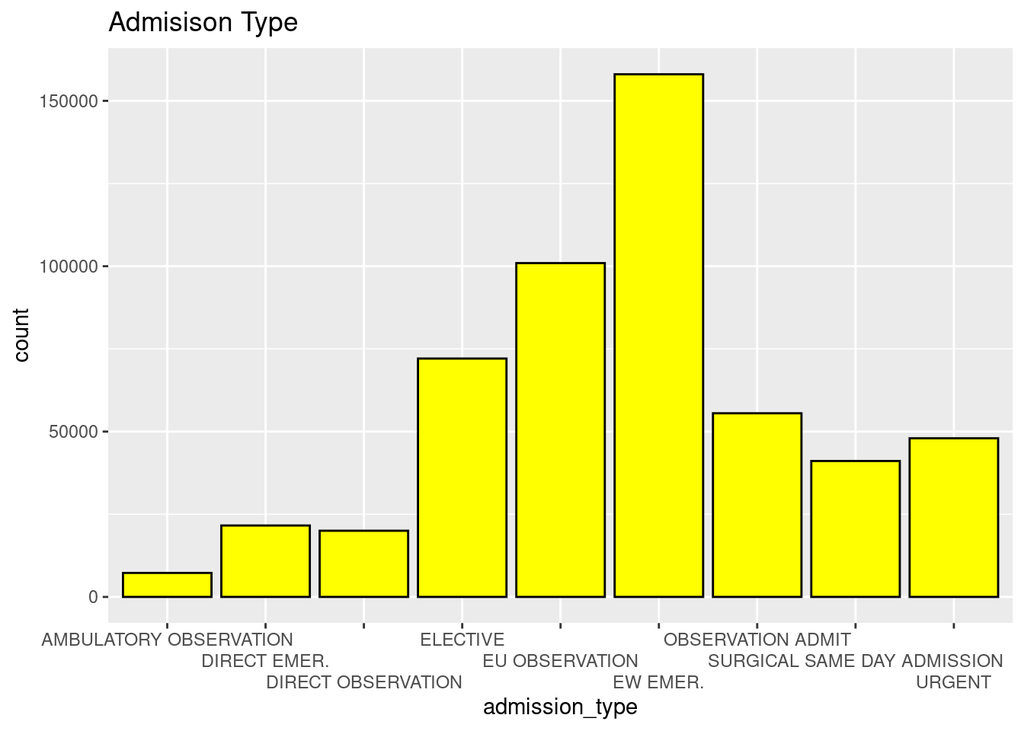

```r
admission %>%
  distinct(., subject_id, .keep = T) %>%
  ggplot(data = admission, mapping = aes(x = admission_type)) +
    stat_count(position = "identity", color = "black", fill = "yellow") +
    scale_x_discrete(guide = guide_axis(n.dodge=3)) +
    labs(title = 'Admisison Type')
```

- number of admissions per patient

```r
admission1 <- admission %>% count(subject_id)
ggplot(data = admission1, mapping = aes(x = n, y = stat(count))) +
  geom_bar() +
  scale_x_continuous(limits = c(0, 30)) +
  xlab("Number of Admissions") +
  ylab("Count")
```

[output not shown]

- admission location

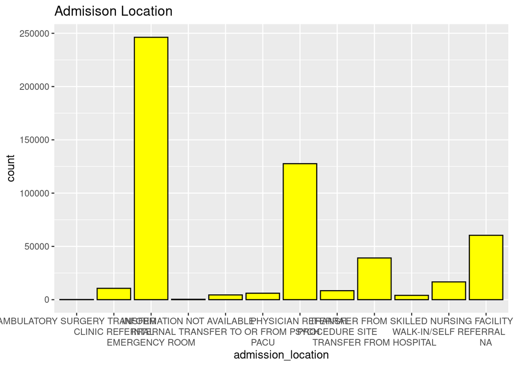

```r
admission %>%
  distinct(., subject_id, .keep = T) %>%
  ggplot(data = admission, mapping = aes(x = admission_location)) +
    stat_count(position = "identity", color = "black", fill = "yellow") +
    scale_x_discrete(guide = guide_axis(n.dodge=3)) +
    labs(title = 'Admisison Location')
```

- discharge location

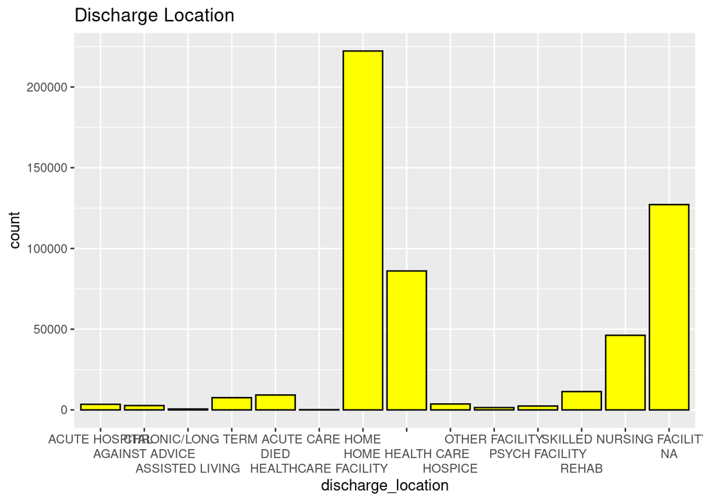

```r
admission %>%
  distinct(., subject_id, .keep = T) %>%
  ggplot(data = admission, mapping = aes(x = discharge_location)) +
    stat_count(position = "identity", color = "black", fill = "yellow") +
    scale_x_discrete(guide = guide_axis(n.dodge=3)) +
    labs(title = 'Discharge Location')
```

- insurance

[figure not shown]

```r
admission %>%
  distinct(., subject_id, .keep = T) %>%
  ggplot(data = admission, mapping = aes(x = insurance)) +
    stat_count(position = "identity", color = "black", fill = "purple") +
    scale_x_discrete(guide = guide_axis(n.dodge=3)) +
    labs(title = 'Discharge Location')
```

- language

[figure not shown]

```r
admission %>%
  distinct(., subject_id, .keep = T) %>%
  ggplot(data = admission, mapping = aes(x = language)) +
    stat_count(position = "identity", color = "black", fill = "purple") +
    scale_x_discrete(guide = guide_axis(n.dodge=3)) +
    labs(title = 'Discharge Location')
```

- martial status

[figure not shown]

```r
admission %>%
  distinct(., subject_id, .keep = T) %>%
  ggplot(data = admission, mapping = aes(x = marital_status)) +
    stat_count(position = "identity", color = "black", fill = "purple") +
    scale_x_discrete(guide = guide_axis(n.dodge=3)) +
    labs(title = 'Discharge Location')
```

- ethnicity

[figure not shown]

```r
admission %>%
  distinct(., subject_id, .keep = T) %>%
  ggplot(data = admission, mapping = aes(x = ethnicity)) +
    stat_count(position = "identity", color = "black", fill = "yellow") +
    scale_x_discrete(guide = guide_axis(n.dodge=3)) +
    labs(title = 'Discharge Location')
```

- death

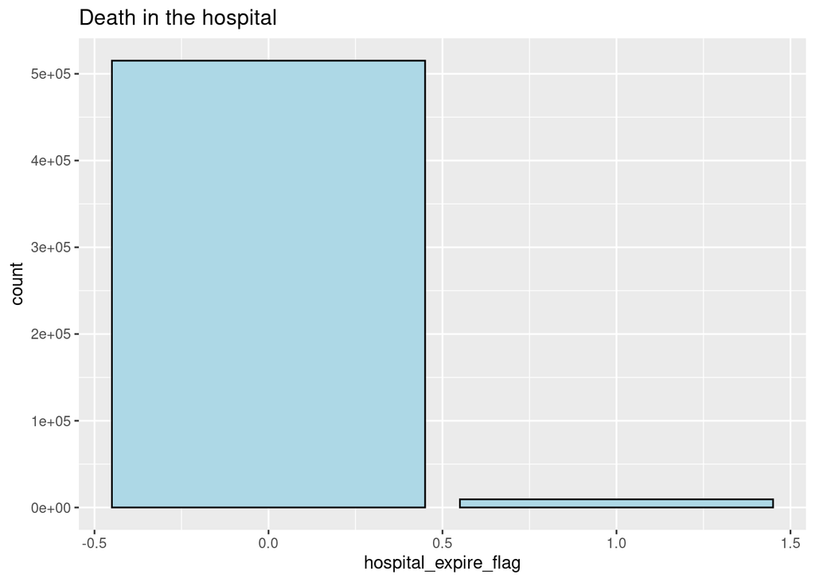

```r
admission %>%
  distinct(., subject_id, .keep = T) %>%
  ggplot(data = admission, mapping = aes(x = hospital_expire_flag)) +
    stat_count(position = "identity", color = "black", fill = "lightblue") +
    labs(title = 'Death in the hospital')
```

```r
    # To show the counts, we can add the following code
    # stat_bin(aes(y=..count.., label=..count..), geom="text")
```

Note it is possible that one patient (uniquely identified by the `SUBJECT_ID`) is admitted into hospital multiple times. When summarizing some demographic information, it makes sense to summarize based on unique patients.

## Q5. `patient` data

Explore `patients.csv.gz` (https://mimic-iv.mit.edu/docs/datasets/core/patients/) and summarize following variables using appropriate numerics and graphs:

### Solution:

Read in the data:

```r
patients <- read_csv(str_c(mimic_path, "/core/patients.csv.gz")) %>%
  print(width = Inf)
```

```
## # A tibble: 383,220 x 6
##    subject_id gender anchor_age anchor_year anchor_year_group dod
##         <dbl> <chr>       <dbl>       <dbl> <chr>             <lgl>
##  1   10002723 F               0        2128 2017 - 2019       NA
##  2   10003939 M               0        2184 2008 - 2010       NA
##  3   10004222 M               0        2161 2014 - 2016       NA
##  4   10005325 F               0        2154 2011 - 2013       NA
##  5   10007338 F               0        2153 2017 - 2019       NA
##  6   10008101 M               0        2142 2008 - 2010       NA
##  7   10009872 F               0        2168 2014 - 2016       NA
##  8   10011333 F               0        2132 2014 - 2016       NA
##  9   10011879 M               0        2158 2014 - 2016       NA
## 10   10012663 F               0        2171 2011 - 2013       NA
## # … with 383,210 more rows
```

- `gender`  
  Number of females: 200226 Number of males: 182994 We can conclude that the distribution of the gender in this dataset is fairly even.

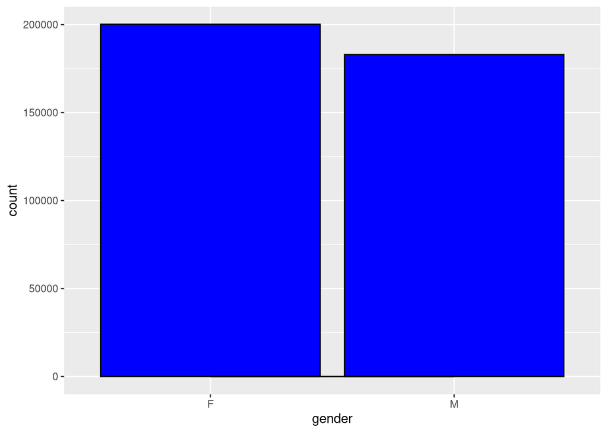

```r
patients %>%
  filter(gender != 0) %>%
  select(gender) %>%
  ggplot(mapping = aes(x = gender)) +
    stat_count(position = "identity", color = "black", fill = "blue", bins = 30) +
    geom_density()
```

- `anchor_age` (explain pattern you see) From the histogram, we can see that most of the patients had an anchor_age around 25, and there was another minor peak aroung the age of 55. Then the density gradually decreased as the anchor_age increasd.

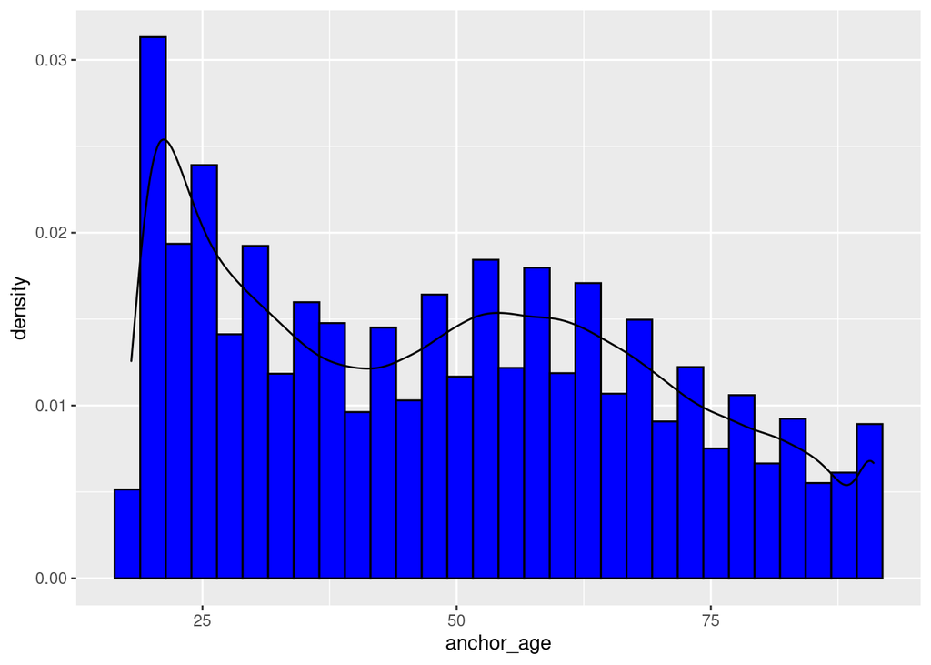

```r
patients %>%
  filter(anchor_age != 0) %>%
  select(anchor_age) %>%
  ggplot(mapping = aes(x = anchor_age)) +
  geom_histogram(aes(y = ..density..), position = "identity",
                 color = "black", fill = "blue") +
  geom_density()
```

## Q6. Lab results

`labevents.csv.gz` (https://mimic-iv.mit.edu/docs/datasets/hosp/labevents/) contains all laboratory measurements for patients.

We are interested in the lab measurements of creatinine, potassium, sodium, chloride, bicarbonate, hematocrit, white blood cell count, glucose, magnesium, calcium, phosphorus, and lactate. Find the `itemid`s of these lab measurements from `d_labitems.csv.gz` and retrieve a subset of `labevents.csv.gz` only containing these items.

Following was the way to read in the file by subsetting the dataset.

```r
icustays_tble <- read_csv(str_c(mimic_path, "/icu/icustays.csv.gz")) %>%
  print(width = Inf)
```

```
## # A tibble: 69,619 x 8
##    subject_id  hadm_id  stay_id first_careunit
##         <dbl>    <dbl>    <dbl> <chr>
##  1   17823467 27561644 35964304 Coronary Care Unit (CCU)
##  2   15772648 26147926 39637383 Trauma SICU (TSICU)
##  3   13713711 25848902 36363748 Trauma SICU (TSICU)
##  4   13173210 22338446 38210858 Coronary Care Unit (CCU)
##  5   10213765 28522861 39765853 Trauma SICU (TSICU)
##  6   17530304 21776160 35848367 Trauma SICU (TSICU)
##  7   10297774 20364526 37788595 Coronary Care Unit (CCU)
##  8   16766597 21185791 39262919 Trauma SICU (TSICU)
##  9   17684317 28656350 36989766 Trauma SICU (TSICU)
## 10   15693895 21203492 34766377 Surgical Intensive Care Unit (SICU)
##    last_careunit                       intime              outtime
##    <chr>                               <dttm>              <dttm>
```

[output cut: 23 more lines]

```r
if(!file.exists("labevents_icustays.csv.gz")){
  system.time(labevents_tble <-
    fread(str_c(mimic_path, "/hosp/labevents.csv.gz"),
      select = c("subject_id", "hadm_id", "itemid","charttime", "valuenum"),
                  nThread = 4))
  labevents_tble %>%
    semi_join(icustays_tble, by = c("subject_id", "hadm_id")) %>%
    fwrite("labevents_icustays.csv.gz", nThread = 4)
}
system.time(labevents_tble <- fread("labevents_icustays.csv.gz"))
labevents_tble %>%
  as.tibble() %>%
  print(width = Inf)
```

[output not shown]

Read in the lab item dictionary

```r
dlabitems <- read_csv(str_c(mimic_path, '/hosp/d_labitems.csv.gz')) %>%
  print (width = Inf)
```

```
## # A tibble: 1,625 x 5
##    itemid label                     fluid            category   loinc_code
##     <dbl> <chr>                     <chr>            <chr>      <chr>
##  1  51898 <NA>                      Other Body Fluid Chemistry  <NA>
##  2  51532 11-Deoxycorticosterone    Blood            Chemistry  <NA>
##  3  51952 17-Hydroxycorticosteroids Urine            Chemistry  <NA>
##  4  51953 17-Ketosteroids, Urine    Urine            Chemistry  <NA>
##  5  52063 24 Hr                     Blood            Hematology <NA>
##  6  51066 24 hr Calcium             Urine            Chemistry  <NA>
##  7  51067 24 hr Creatinine          Urine            Chemistry  <NA>
##  8  51068 24 hr Protein             Urine            Chemistry  <NA>
##  9  50853 25-OH Vitamin D           Blood            Chemistry  <NA>
## 10  51533 3t                        Blood            Chemistry  <NA>
## # … with 1,615 more rows
```

Lab items that are related to creatinine:

```r
labitem <- 'creatinine'
creatinine_items <- dlabitems %>%
  filter(str_detect(label, regex(labitem, ignore_case = T))) %>%
  print(width = Inf)
```

```
## # A tibble: 20 x 5
##    itemid label                           fluid               category
##     <dbl> <chr>                           <chr>               <chr>
##  1  51067 24 hr Creatinine                Urine               Chemistry
##  2  51070 Albumin/Creatinine, Urine       Urine               Chemistry
##  3  51958 Amylase/Creatinine Clearance    Urine               Chemistry
##  4  51073 Amylase/Creatinine Ratio, Urine Urine               Chemistry
##  5  50912 Creatinine                      Blood               Chemistry
##  6  52541 Creatinine                      Blood               Chemistry
##  7  50841 Creatinine, Ascites             Ascites             Chemistry
##  8  51972 Creatinine, Blood               Urine               Chemistry
##  9  51032 Creatinine, Body Fluid          Other Body Fluid    Chemistry
## 10  51080 Creatinine Clearance            Urine               Chemistry
## 11  51785 Creatinine, CSF                 Cerebrospinal Fluid Chemistry
## 12  51021 Creatinine, Joint Fluid         Joint Fluid         Chemistry
```

[output cut: 30 more lines]

```r
labitems <- c("creatine", "postassium", "sodium", "chloride",
             "bicarbonate", "hematocrit", "white blood cell",
             "glucose", "magnesium", "calcium", "lactate")
itemids <- rep(0, length(labitems))
i <- 1
for (labitem in labitems) {
  print(str_interp("search for ${labitem}"))
  itemid_list <- dlabitems %>%
    filter(str_detect(lable, regex(labitem, ignore_case = T))) %>%
    .$itemid
  itemid <- labevents_tble %>%
    filter(itemid %in% itemid_list) %>%
    count(itemid) %>%
    arrange(desc(n)) %>%
    .$itemid
  itemid[i] <- itemid
  i <- i+1
}
```

[output not shown]

```r
labitem_itemid <- tibble (itemid = itemids, labitem = labitems) %>%
  print(width = Width)
```

[output not shown]

Finally, filter the rows that only contains these items:

```r
labevents_tble <- labevents_tble %>%
  as_tibble() %>%
  filter(itemid %in% labitem_itemid$itemid) %>%
  mutate(charttime = ymd_hms(charttime)) %>%
  print(width = Inf)
```

[output not shown]

## Q7. Vitals from chartered events

We are interested in the vitals for ICU patients: heart rate, mean and systolic blood pressure (invasive and noninvasive measurements combined), body temperature, SpO2, and respiratory rate.

`chartevents.csv.gz` (https://mimic-iv.mit.edu/docs/datasets/icu/chartevents/) contains all the charted data available for a patient. During their ICU stay, the primary repository of a patient’s information is their electronic chart. The `ITEMID` variable indicates a single measurement type in the database. The `VALUE` variable is the value measured for `ITEMID`.

`d_items.csv.gz` (https://mimic-iv.mit.edu/docs/datasets/icu/d_items/) is the dictionary for the `ITEMID` in `CHARTEVENTS.csv`. Find potential values of `ITEMID` that correspond to systolic blood pressure, i.e., `LABEL` contains the string `systolic`.

### Solution:

Read in dictionary for chartevent:

```r
dchartitems_tble <- read_csv(str_c(mimic_path, "/icu/d_items.csv.gz")) %>%
  print(width = Inf)
```

```
## # A tibble: 3,835 x 9
##    itemid label                                abbreviation       linksto
##     <dbl> <chr>                                <chr>              <chr>
##  1 220003 ICU Admission date                   ICU Admission date datetimeevents
##  2 220045 Heart Rate                           HR                 chartevents
##  3 220046 Heart rate Alarm - High              HR Alarm - High    chartevents
##  4 220047 Heart Rate Alarm - Low               HR Alarm - Low     chartevents
##  5 220048 Heart Rhythm                         Heart Rhythm       chartevents
##  6 220050 Arterial Blood Pressure systolic     ABPs               chartevents
##  7 220051 Arterial Blood Pressure diastolic    ABPd               chartevents
##  8 220052 Arterial Blood Pressure mean         ABPm               chartevents
##  9 220056 Arterial Blood Pressure Alarm - Low  ABP Alarm - Low    chartevents
## 10 220058 Arterial Blood Pressure Alarm - High ABP Alarm - High   chartevents
##    category            unitname param_type    lownormalvalue highnormalvalue
##    <chr>               <chr>    <chr>                  <dbl>           <dbl>
##  1 ADT                 <NA>     Date and time             NA              NA
##  2 Routine Vital Signs bpm      Numeric                   NA              NA
##  3 Alarms              bpm      Numeric                   NA              NA
##  4 Alarms              bpm      Numeric                   NA              NA
##  5 Routine Vital Signs <NA>     Text                      NA              NA
##  6 Routine Vital Signs mmHg     Numeric                   90             140
##  7 Routine Vital Signs mmHg     Numeric                   60              90
##  8 Routine Vital Signs mmHg     Numeric                   NA              NA
##  9 Alarms              mmHg     Numeric                   NA              NA
## 10 Alarms              mmHg     Numeric                   NA              NA
## # … with 3,825 more rows
```

Inspect itemids corresponding to the items we require:

```r
for (chartitem in c("heart rate", "Blood Pressure mean", "systolic",
                    "temperature", "Sp02", "respiratory rate")) {
  print(str_interp("search for ${chartitem}"))
  dchartitems_tble %>%
    filter(str_detect(label, regex(chartitem, ignore_case = T))) %>%
    print (width = Inf)
  }
```

```
## [1] "search for heart rate"
## # A tibble: 3 x 9
##   itemid label                   abbreviation    linksto     category
##    <dbl> <chr>                   <chr>           <chr>       <chr>
## 1 220045 Heart Rate              HR              chartevents Routine Vital Signs
## 2 220046 Heart rate Alarm - High HR Alarm - High chartevents Alarms
## 3 220047 Heart Rate Alarm - Low  HR Alarm - Low  chartevents Alarms
##   unitname param_type lownormalvalue highnormalvalue
##   <chr>    <chr>               <dbl>           <dbl>
## 1 bpm      Numeric                NA              NA
## 2 bpm      Numeric                NA              NA
## 3 bpm      Numeric                NA              NA
## [1] "search for Blood Pressure mean"
## # A tibble: 2 x 9
##   itemid label                            abbreviation linksto
```

[output cut: 91 more lines]

```r
chartitem_itemid <- dchartitems_tble %>%
  filter(itemid %in% c(220045, 220052, 220181, 220179,
                       220050, 223761, 229862, 220210)) %>%
  print (width = Inf)
```

[output not shown]

Then the part I kept fail was to read in the `chartevents.csv.gz` file, which I could not get run on the server. I have tried to download it to local but the server kept crushing while downloading.

## Q8. Putting things together

Let us create a tibble for all ICU stays, where rows are

- first ICU stay of each unique patient
- adults (age at admission > 18)

and columns contains at least following variables

- all variables in `icustays.csv.gz`
- all variables in `admission.csv.gz`
- first lab measurements during ICU stay
- first vitals measurement during ICU stay
- an indicator variable whether the patient died within 30 days of hospital admission

```r
icustays %>%
  group_by(subject_id) %>%
  filter(rank(intime) == 1) %>%
  ungroup() %>%
  left_join(admission, by = c("subject_id", "hadm_id")) %>%
  left_join(patients, by = "subject_id") %>%
  mutate(age_at_adm = year(admittime) - anchor_year + anchor_age) %>%
  filter(age_at_birth > 18) %>%
  print(width = Inf)
```

[output not shown]